# EDS 223: assignment 1

Colleen McCamy

2022-09-28

## introduction

The following exercises are modified from [Chapter 9 of Geocomputation with R by Rovin Lovelace](https://geocompr.robinlovelace.net/adv-map.html). Each question lists the total number of points. The breakdown of points can be found at the end of each instruction in parentheses. A general grading rubric can be found on the [course website](https://ryoliver.github.io/EDS_223_spatial_analysis/assignments.html).

**Please update “author” to list your first and last names and any collaborators (e.g. Ruth Oliver, Friend1, Friend2)**

**Due by midnight Saturday 2022-10-08**

## prerequisites

```r
library(sf)
library(raster)
library(dplyr)
library(spData)
library(spDataLarge)
library(tmap)
library(leaflet)
```

These exercises rely on a new data object based on the **world** and **worldbank_df** datasets from the **spData* package.

```r
africa = world |>
  filter(continent == "Africa", !is.na(iso_a2)) |>
  left_join(worldbank_df, by = "iso_a2") |>
  dplyr::select(name, subregion, gdpPercap, HDI, pop_growth) |>
  st_transform("+proj=aea +lat_1=20 +lat_2=-23 +lat_0=0 +lon_0=25")

#QUESTION: what is the st_transform doing in this code above?
```

We will also use the **zion** and **nlcd** datasets from the **spDataLarge** package.

```r
zion = st_read((system.file("vector/zion.gpkg", package = "spDataLarge")))
data(nlcd, package = "spDataLarge")
force(nlcd)
```

```
## class      : RasterLayer
## dimensions : 1359, 1073, 1458207  (nrow, ncol, ncell)
## resolution : 31.5303, 31.52466  (x, y)
## extent     : 301903.3, 335735.4, 4111244, 4154086  (xmin, xmax, ymin, ymax)
## crs        : +proj=utm +zone=12 +ellps=GRS80 +towgs84=0,0,0,0,0,0,0 +units=m +no_defs
## source     : memory
## names      : layer
## values     : 1, 8  (min, max)
## attributes :
##        ID  colors   levels
##  from:  1 #476ba0    Water
##   to :  8 #bad8ea Wetlands
```

```r
#QUESTION: what is force doing here too I saw that it brought mlcd from "value" to "data" in the environment and that it forces that evaluation of a function argument
```

## question 1

##### 10 points

Create a map showing the geographic distribution of the Human Development Index (HDI) across Africa.  
- use both base graphics (hint: use **plot()**) and **tmap**) (4)  
- name two advantages of each based on the experience (3) - name three other mapping packages and an advantage of each (3)

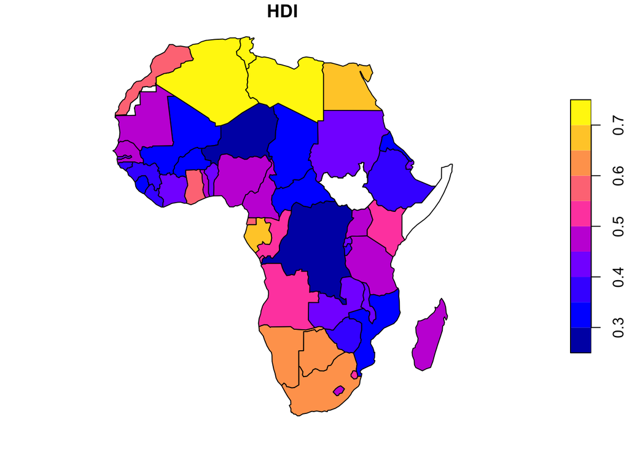

```r
#- Creating a map of HDI across Africa using plot()
plot_HDI <- plot(africa["HDI"])
```

```r
#------ calling the plot back to view
plot_HDI
```

[output not shown]

[output cut: 139 more lines]

[output not shown]

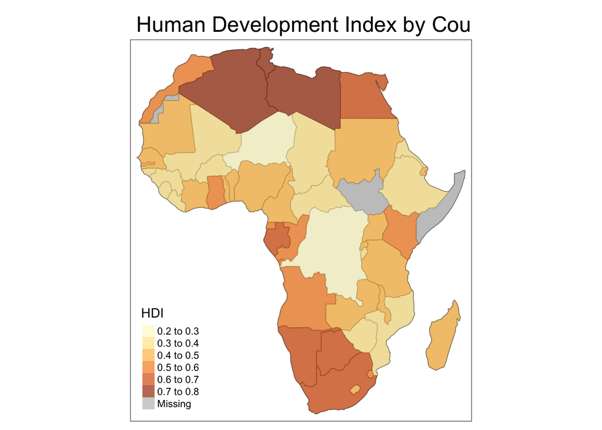

```r
#-Creating a map of HDI across Africa using tmap()

#------ storing map polygon map of africa
map_africa <- tm_shape(africa) +
  tm_polygons()
#------ building on the map to fill by HDI
tmap_HDI <- map_africa +
  tm_shape(africa) +
  tm_fill(col = "HDI", alpha = 0.7) +
  tm_layout(main.title = "Human Development Index by Country")
#------ calling the plot back to view
tmap_HDI
```

**Two advantages of plot() and tmap():**

- Advantages Using plot():
  - There is less lines of code required for the plot() function in comparison to tmap(). For this example, the plot function only required one line of code for plot() while tmap() we need to specify the t_shape and data in addition to the geometry aspect that will be plotted (fill for this case.)
  - Borders are automatically included within the map with plot() while with tmap() you need to specify that you want to include borders either with tm_borders() or tm_polygons() to have borders included.
- Advantages of tmap():
  - The legend with tmap() automatically labels and illustrates which color is associated with areas that have a missing while in plot() it was just blank without any indication that they were missing values.
  - The automatically populated legend is more clear in that it shows the range of HDI for each color, whereas for plot() on the HDI numbers are specified for every other color grouping.

**Three other mapping applications and advantages:**

- The **googleway** package provides interactive maps that are flexible and extensible.
- Another mapping application, **mapdeck**, allows for visualizations of large datasets (up to 1,000,000 points) that are interactive.
- **GeoDjango** allows for additional functionality for interactive maps and expands user interface to be more fluid, and provides space for additional interactivity between variable relationships and more.

## question 2

##### 20 points

Extend the **tmap** created for question 1 so the legend has three bins: “high” (HDI above 0.7), “medium” (HDI between 0.55 and 0.7), and “low” (HDI below 0.55). (5)  
- change the legend title (5)  
- change the class labels (5)  
- change the color palette (5)

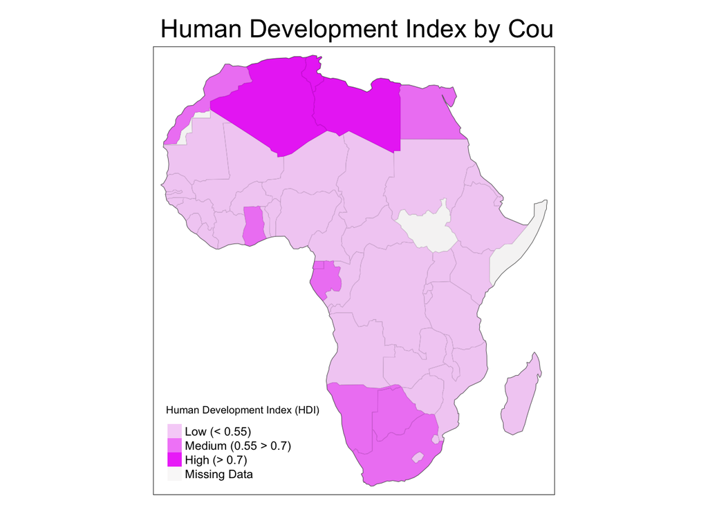

```r
#updating tmap_HDI and storing it as tmap_HDI_2 to show the changes
tmap_HDI_2 <- map_africa +
  tm_shape(africa) +
  tm_fill(col = "HDI",
          alpha = 0.9,
          stye = "fixed",
          textNA = "Missing Data",
          colorNA = "#F9F8F8",
          title = "Human Development Index (HDI)",
          breaks = c(0, 0.55, 0.7, Inf),
          palette = c("#F5CFF7", "#F17FF7", "#EC13F8"),
          labels = c("Low (< 0.55)",
                     "Medium (0.55 > 0.7)",
                     "High (> 0.7)")) +
  tm_layout(main.title = "Human Development Index by Country")

#calling the map back
tmap_HDI_2
```

## question 3

##### 20 points

Represent Africa’s subregions on the map. (5)  
- change the color palette (5)  
- change the legend title (5)  
- combine this map with the map from question 2 into a single plot (5)

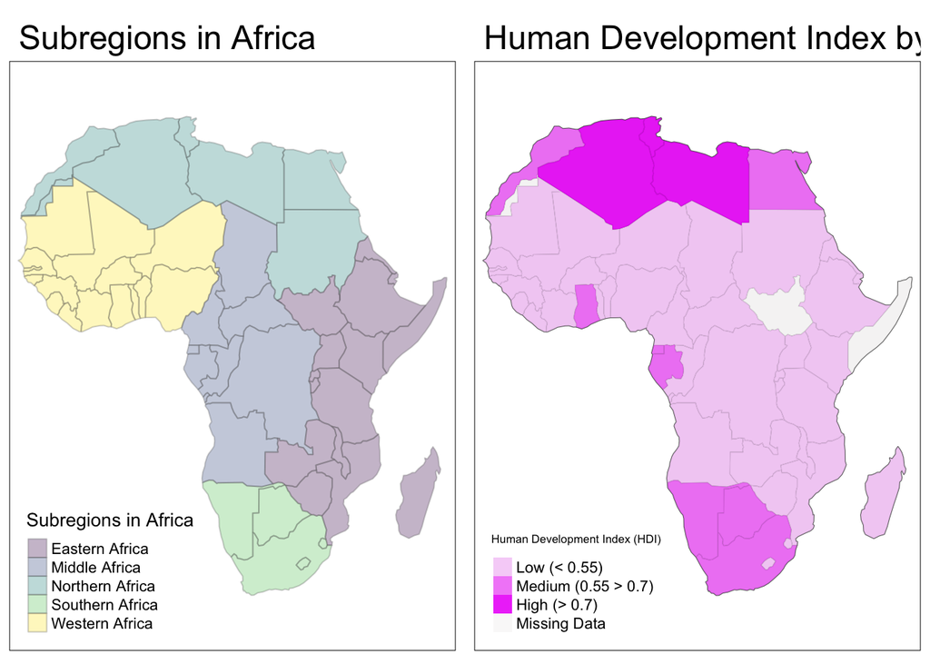

```r
# ----- creating a map of Africa's subregions
map_afr_subreg <- tm_shape(africa)+
  tm_fill(col = "subregion",
          palette = "viridis", #changing the color palette
          title = "Subregions in Africa",
          alpha = 0.3) +
  tm_layout(main.title = "Subregions in Africa") +
  tm_borders(alpha = 0.3)

# ----- combining the two maps and storing it as a separate map
map_afr_subreg_hdi <- tmap_arrange(map_afr_subreg, tmap_HDI_2)

map_afr_subreg_hdi
```

## question 4

##### 30 points

Create a land cover map of Zion National Park (5)  
- change the default colors to match your perception of land cover categories (5)  
- move the map legend outside of the map to improve readability (5)  
- add a scale bar and north arrow and change the position of both to improve the maps aesthetics (5)  
- add the park boundaries on top of the land cover map (5)  
- add an inset of Zion’s location in the context of the state of Utah (5)  
- hint: an object representing Utah can be subset from the **us_states** dataset)

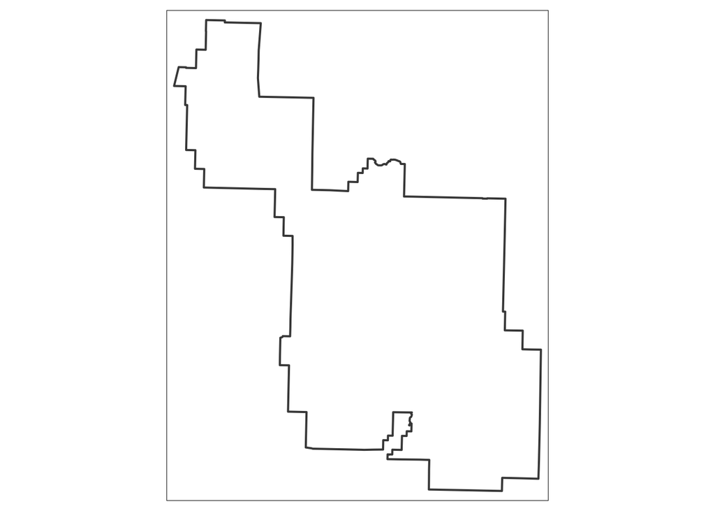

```r
#----- filtering the us_states data to provide information for Utah and the western region
us_states_west <- us_states |>
  filter(REGION == "West")
us_states_utah <- us_states |>
  filter(NAME == "Utah")


# ------ creating a map of Zion's borders
zion_map <- tm_shape(zion)+
  tm_borders(lwd = 2, col = "#474747")

zion_map
```

```
## stars object downsampled to 888 by 1125 cells. See tm_shape manual (argument raster.downsample)
```

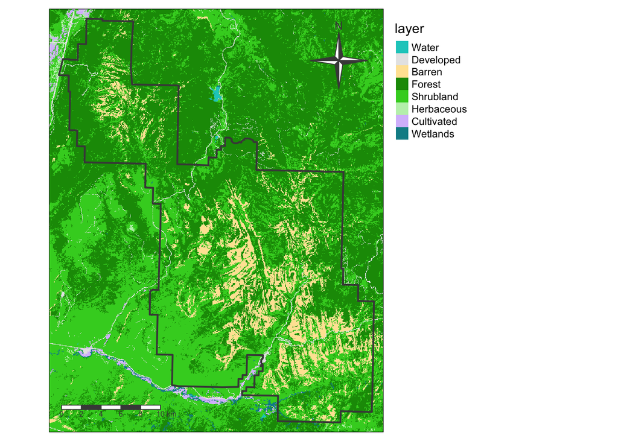

```r
# creating a map of Utah and adding the Zion map
utah_map <- tm_shape(us_states_utah) +
  tm_borders() +
  tm_layout(title = "Utah") +
  zion_map +
  tm_fill()

# mapping the National Land Cover Data and adding the map of Zion ontop
map_zion_nlcd <-tm_shape(nlcd)+
  tm_raster(palette = c("#11CCC6",
                        "#E6E6E6",
                        "#FFE4A2",
                        "#179705",
                        "#3CD027",
                        "#BFF0B8",
                        "#D7BFFB",
                        "#058D95")) +
  tm_scale_bar(color.dark="#474747",
               text.color = "#474747",
               position = c("left")) +
  tm_compass(type = "4star",
             position = c("right", "top"),
             color.dark = "#474747",
             text.color = "#474747") +
  tm_layout(legend.outside = TRUE) +
  zion_map

map_zion_nlcd
```

```r
# adding the inset map of utah to the zion land use map
library(grid)
map_zion_nlcd
```

```
## stars object downsampled to 888 by 1125 cells. See tm_shape manual (argument raster.downsample)
```

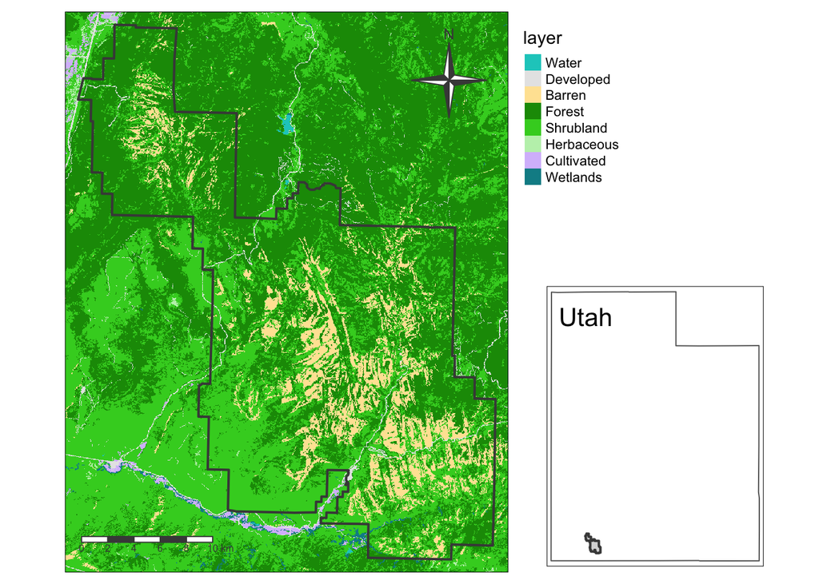

```r
print(utah_map, vp = viewport(0.8, 0.27, width = 0.5, height = 0.5))
```

```r
#tmap_mode(plot)
# this code can above can be used to switch from an interactive map to a static map
```